# Report, Summary

CAST

Ann.Lincoln

2019-12-05 11:59:36

# **REPORT INFORMATION**

**Report Date and Time:** 2019-12-05 11:59:36

**Generated By:** Ann.Lincoln

**CASTfxn Package Version:** 0.1.0.9235

**Selected parameters:**

```
Remove outliers? TRUE
Use expected biological similarity filter? TRUE
Number of days lag time between stressor and response sample collection = 10
Quality of site displayed on analysis graphics? Not degraded
Lower and upper quantiles for identifying stressors = 0.25-0.75
```

# **SITE INFORMATION**

**Site ID:** 907S05514

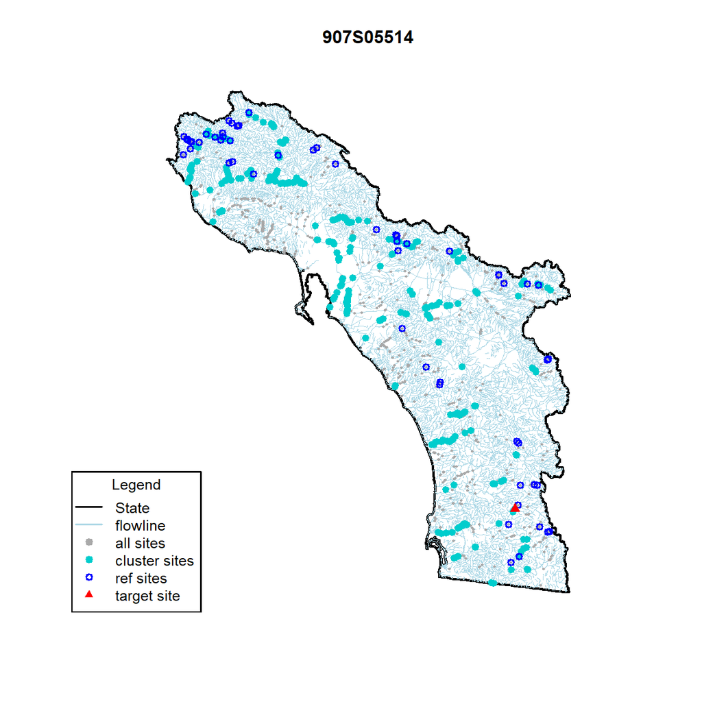

## *Site Photos*

All media files are in the ‘Results/SiteInfo/Photos’ folder. Images are shown here.

[figure not shown]

[figure not shown]

[figure not shown]

## *Site Background*

All background bar graphs are in the ‘Results/SiteInfo’ folder. Selected graphics are shown here.

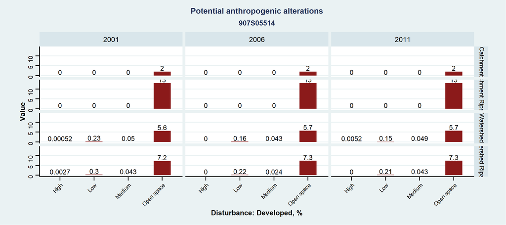

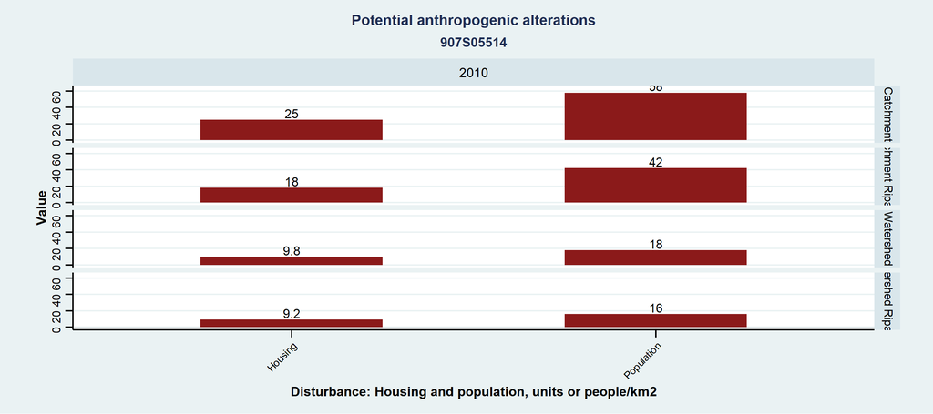

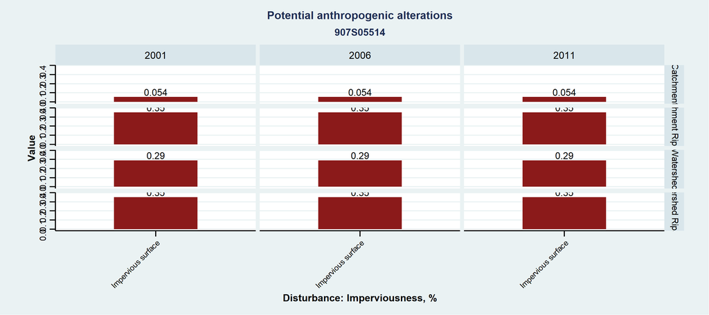

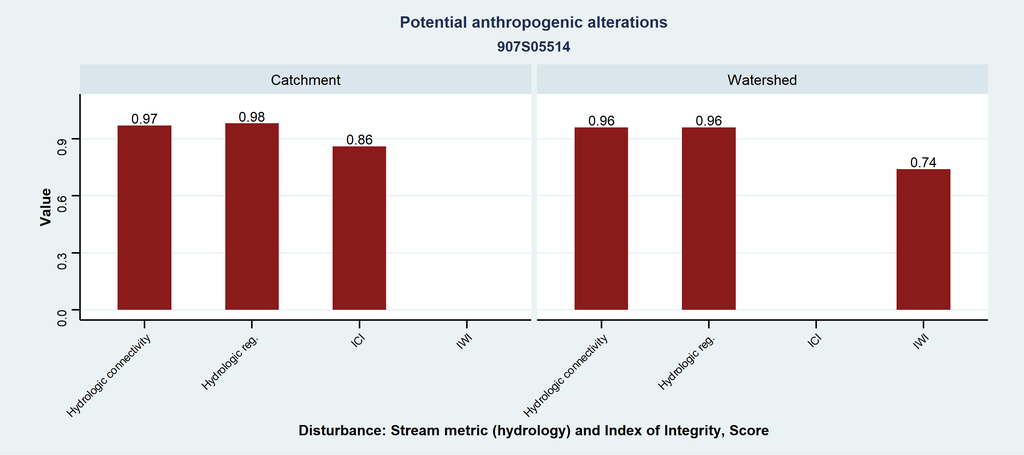

## *Site Sample Summary*

Samples collected from 907S05514 over time.

| StationID_Master | COMID | Cluster | SampleDate | ChemSampleID | PhabSampID | FldChemSampID | FlowSampID | BMISampID | AlgSampID | EpiphyteSampID | IntegAlgSampID | MacroalgSampID | MicroalgSampID |
| --- | --- | --- | --- | --- | --- | --- | --- | --- | --- | --- | --- | --- | --- |
| 907S05514 | 20332496 | 5 | 2011-05-18 | 907S05514_2011-05-18 | 907S05514_2011-05-18 | NA | 907S05514_modeledflow | 907S05514_5/18/2011_BMI_RWB_2 | 907S05514_5/18/2011_2 | NA | 907S05514_5/18/2011_2 | NA | 907S05514_5/18/2011_2 |
|  |  |  | 2011-05-18 | 907S05514_2011-05-18 | 907S05514_2011-05-18 | NA | 907S05514_modeledflow | 907S05514_5/18/2011_BMI_RWB_2 | 907S05514_5/18/2011_1 | NA | 907S05514_5/18/2011_1 | NA | 907S05514_5/18/2011_1 |
|  |  |  | 2011-05-18 | 907S05514_2011-05-18 | 907S05514_2011-05-18 | NA | 907S05514_modeledflow | 907S05514_5/18/2011_BMI_RWB_1 | 907S05514_5/18/2011_2 | NA | 907S05514_5/18/2011_2 | NA | 907S05514_5/18/2011_2 |
|  |  |  | 2011-05-18 | 907S05514_2011-05-18 | 907S05514_2011-05-18 | NA | 907S05514_modeledflow | 907S05514_5/18/2011_BMI_RWB_1 | 907S05514_5/18/2011_1 | NA | 907S05514_5/18/2011_1 | NA | 907S05514_5/18/2011_1 |

# **BMI RESULTS**

## *Biological Index Distributions*

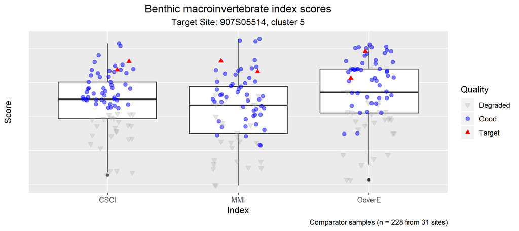

## *Comparator Site Information*

Additional comparator site info, including a list of comparator sites can be found in the ‘Results/SiteInfo’ foler.

Number of sites by type, group, and quality.

| Group | Quality | ComparatorSites | ClusterSites | AllSites |
| --- | --- | --- | --- | --- |
| All | All qualities | 36 | 305 | 1141 |
|  | Degraded | 6 | 155 | 550 |
|  | Not degraded | 30 | 150 | 591 |
| Better than | All qualities | 3 | 8 | 68 |
|  | Degraded | 0 | 0 | 0 |
|  | Not degraded | 3 | 8 | 68 |

## *Potential Candidate Causes*

Stressors identified candidate causes include AFDM_algae_particulate_g_m2, Cadmium_tot_mg_kg_dw, Caffeine_ug_L, Chromium_tot_mg_kg_dw, Iron_f_ug_L, Silver_f_ug_L, Silver_tot_mg_kg_dw, MaxMonthQ_Wet.

All stressor box plots are in the file ‘907S05514_BMI_CandCauses_ALL.pdf’ in the’Results/CandidateCauses’ folder.

Box plots are arranged by stressor category. Stressors requiring further evaluation fall outside the 0.25-0.75 quantile range.

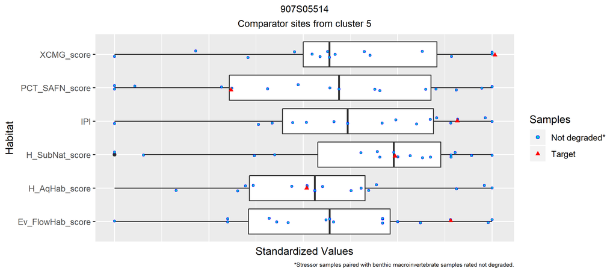

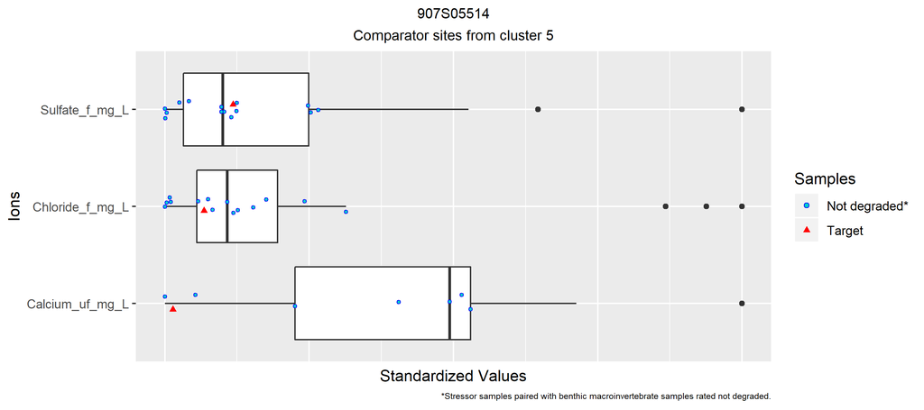

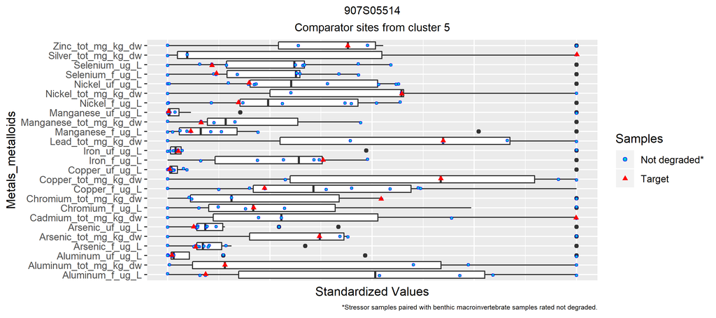

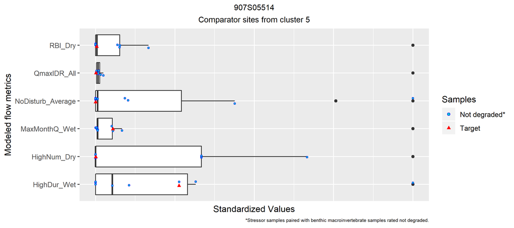

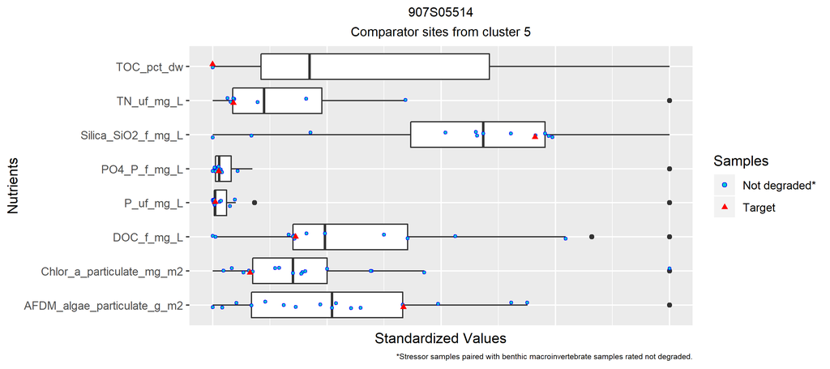

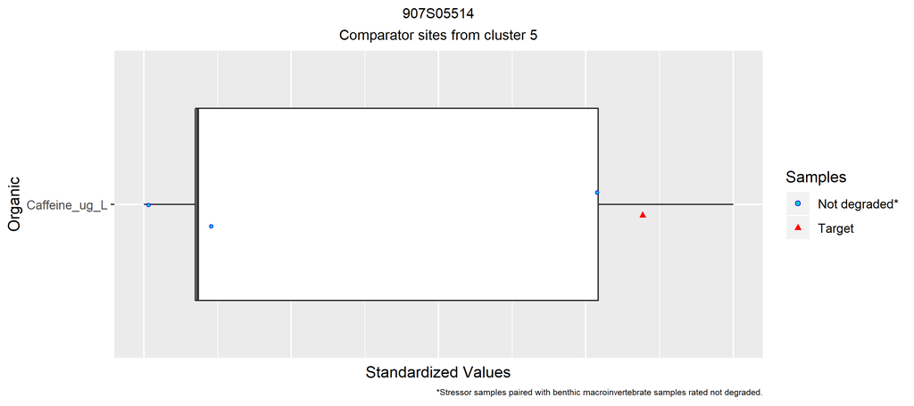

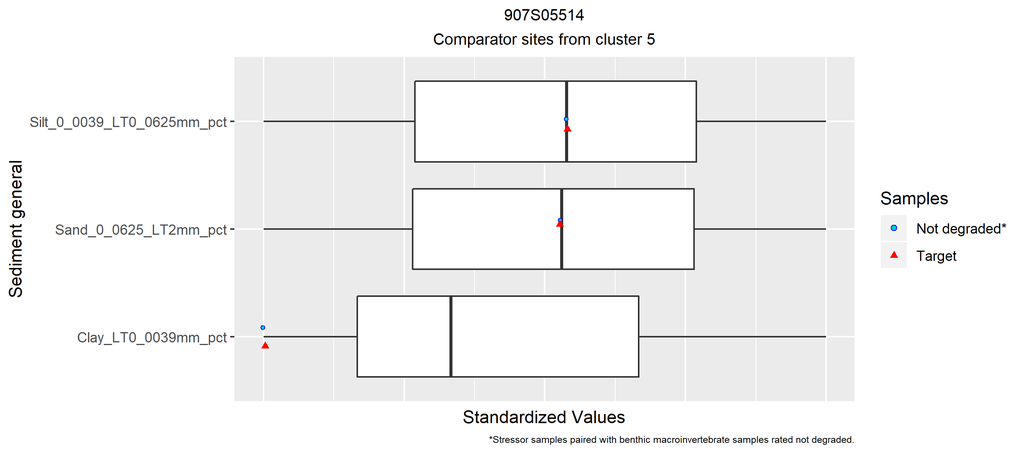

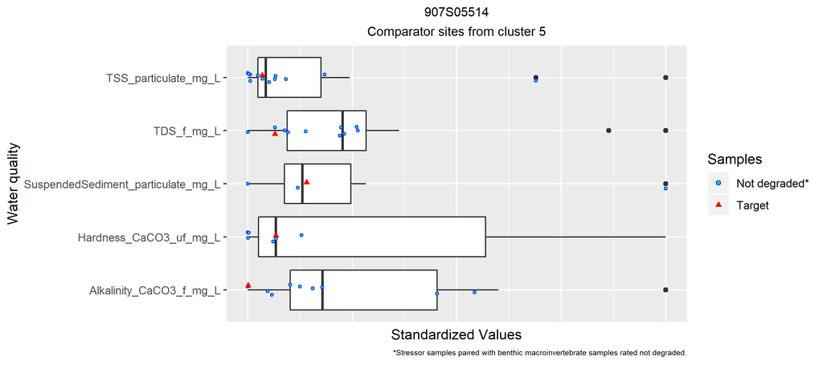

## *Weight of Evidence*

### Overall Findings

Weight of evidence data are found in the file ‘907S05514_BMI_WoE_ExecSummary.tab’ in the’C:/Users/ann.lincoln/Documents/SEP_CAST/Results/907S05514/BMI/WoE’ folder. Weight of evidence data are found in the file ‘907S05514_BMI_WoE_ScoresTable.tab’ in the’C:/Users/ann.lincoln/Documents/SEP_CAST/Results/907S05514/BMI/WoE’ folder.

Scores for each line of evidence and overall weight of evidence, weighted by number of stressors in each group.

| SiteID | Degraded | Group | Samples | Stressors | CO_boxplot | SR_Outside_LinRegr | SR_Inside_LinRegr | SR_Inside_LogRegr | VP_Boxplot | Overall_WoE |
| --- | --- | --- | --- | --- | --- | --- | --- | --- | --- | --- |
| 907S05514 | No | Metals_metalloids | 1 | 5 | 0.8 | 0.2 | 0 | -0.2 | 0 | 0.2 |
|  |  | Nutrients | 1 | 1 | 0.0 | 0.0 | 0 | 0.0 | 0 | 0.0 |
|  |  | Organic | 1 | 1 | 0.0 | 0.0 | 0 | 0.0 | 0 | 0.0 |
|  |  | Modeled flow metrics | 1 | 1 | 0.0 | 1.0 | 1 | 1.0 | 0 | 1.0 |

### Stressor Scores

Scores for each line of evidence equal 1 (supports), -1 (refutes), 0 (indeterminate), or NE (not evaluated).

| Degraded | Narrative | CSCI | ResponseSampleDate | ResponseSampleID | StressorSampleDate | StressorSampleID | Group | Stressor | StressorValue | PercentRank | WoE | CO_boxplot | SR_Inside_LogRegr | SR_Inside_LinRegr | SR_Outside_LinRegr | VP_SensitiveTaxa | VP_TolerantTaxa | SSD_ToxicityCurve | TotSupport | TotRefute | TotIndet | TotNotEval |
| --- | --- | --- | --- | --- | --- | --- | --- | --- | --- | --- | --- | --- | --- | --- | --- | --- | --- | --- | --- | --- | --- | --- |
| No | likely intact | 1.154 | 2011-05-18 | 907S05514_5/18/2011_BMI_RWB_1 | 2011-05-18 | 907S05514_2011-05-18 | Metals_metalloids | Cadmium_tot_mg_kg_dw | 0.4200 | 1.000 | Supports | 1 | 0 | 0 | 1 | NE | NE | NE | 2 | 0 | 2 | 4 |
|  |  | 1.094 |  | 907S05514_5/18/2011_BMI_RWB_2 |  |  |  | Cadmium_tot_mg_kg_dw | 0.4200 | 1.000 | Supports | 1 | 0 | 0 | 1 | NE | NE | NE | 2 | 0 | 2 | 4 |
|  |  | 1.154 |  | 907S05514_5/18/2011_BMI_RWB_1 |  |  |  | Chromium_tot_mg_kg_dw | 57.20 | 0.833 | Indeterminate | 1 | -1 | 0 | 0 | NE | NE | NE | 1 | 1 | 2 | 4 |
|  |  | 1.094 |  | 907S05514_5/18/2011_BMI_RWB_2 |  |  |  | Chromium_tot_mg_kg_dw | 57.20 | 0.833 | Indeterminate | 1 | -1 | 0 | 0 | NE | NE | NE | 1 | 1 | 2 | 4 |
|  |  | 1.154 |  | 907S05514_5/18/2011_BMI_RWB_1 |  |  |  | Iron_f_ug_L | 102 | 0.778 | Indeterminate | 1 | 0 | 0 | 0 | NE | NE | NE | 1 | 0 | 3 | 4 |
|  |  | 1.094 |  | 907S05514_5/18/2011_BMI_RWB_2 |  |  |  | Iron_f_ug_L | 102 | 0.778 | Indeterminate | 1 | 0 | 0 | 0 | NE | NE | NE | 1 | 0 | 3 | 4 |
|  |  | 1.154 |  | 907S05514_5/18/2011_BMI_RWB_1 |  |  |  | Silver_f_ug_L | 0.0800 | 1.000 | Indeterminate | 1 | 0 | 0 | 0 | NE | NE | NE | 1 | 0 | 3 | 4 |
|  |  | 1.094 |  | 907S05514_5/18/2011_BMI_RWB_2 |  |  |  | Silver_f_ug_L | 0.0800 | 1.000 | Indeterminate | 1 | 0 | 0 | 0 | NE | NE | NE | 1 | 0 | 3 | 4 |
|  |  | 1.154 |  | 907S05514_5/18/2011_BMI_RWB_1 |  |  |  | Silver_tot_mg_kg_dw | 0.7200 | 1.000 | Indeterminate | 0 | 0 | 0 | 0 | NE | NE | NE | 0 | 0 | 4 | 4 |
|  |  | 1.094 |  | 907S05514_5/18/2011_BMI_RWB_2 |  |  |  | Silver_tot_mg_kg_dw | 0.7200 | 1.000 | Indeterminate | 0 | 0 | 0 | 0 | NE | NE | NE | 0 | 0 | 4 | 4 |
|  |  | 1.154 |  | 907S05514_5/18/2011_BMI_RWB_1 |  |  | Nutrients | AFDM_algae_particulate_g_m2 | 30.98 | 0.750 | Indeterminate | 0 | 0 | 0 | 0 | NE | NE | NE | 0 | 0 | 4 | 4 |
|  |  | 1.094 |  | 907S05514_5/18/2011_BMI_RWB_2 |  |  |  | AFDM_algae_particulate_g_m2 | 30.98 | 0.750 | Indeterminate | 0 | 0 | 0 | 0 | NE | NE | NE | 0 | 0 | 4 | 4 |
|  |  | 1.154 |  | 907S05514_5/18/2011_BMI_RWB_1 |  |  | Organic | Caffeine_ug_L | 0.7840 | 0.750 | Indeterminate | 0 | 0 | 0 | 0 | NE | NE | NE | 0 | 0 | 4 | 4 |
|  |  | 1.094 |  | 907S05514_5/18/2011_BMI_RWB_2 |  |  |  | Caffeine_ug_L | 0.7840 | 0.750 | Indeterminate | 0 | 0 | 0 | 0 | NE | NE | NE | 0 | 0 | 4 | 4 |
|  |  | 1.154 |  | 907S05514_5/18/2011_BMI_RWB_1 |  |  | Modeled flow metrics | MaxMonthQ_Wet | 0.0123 | 0.800 | Supports | 0 | 1 | 1 | 1 | NE | NE | NE | 3 | 0 | 1 | 4 |
|  |  | 1.094 |  | 907S05514_5/18/2011_BMI_RWB_2 |  |  |  | MaxMonthQ_Wet | 0.0123 | 0.800 | Supports | 0 | 1 | 1 | 1 | NE | NE | NE | 3 | 0 | 1 | 4 |

# **ALGAE RESULTS**

## *Biological Index Distributions*

No algal data for 907S05514.

## *Comparator Site Information*

No algal data for 907S05514.

## *Potential Candidate Causes*

No algal data for 907S05514.

## *Weight of Evidence*

### Overall Findings

No algal data for 907S05514.

### Stressor Scores

No algal data for 907S05514.